### 1월/3주

#### ▶ ▣ 정당지지도 ▣

더불어민주당 43.4%, 국민의힘 38.1%, 정의당 1.5%, 기타 정당 4.9%, 지지하는 정당이 없다 11.5%, 잘 모르겠다 0.7%

#### ▶ ▣ 대통령 국정 수행 평가 ▣

잘하고 있다 39.3%, 잘못하고 있다 58.7%, 잘 모르겠다 2.0%

#### ☑ ▣ 총선 프레임 공감 ▣

원활한 국정수행을 뒷받침하기 위해 여당인 국민의힘에 힘을 실어 줘야 한다 36.8%, 현 정권 견제를 위해서 제1야당인 민주당에 힘을 실어 줘야 한다 44.7%, 기존 양당이 아닌 제3세력에 힘을 실어 줘야 한다 18.5%

#### ☑ ▣ 총선 투표 정당 ▣

더불어민주당 42.4%, 국민의힘 34.7%, 정의당 연합신당 1.5%, 한국의 희망 1.2%, 새로운 선택 1.9%, 이낙연 신당 4.3%, 이준석 신당 9.7%, 그 외 다른 정당 1.8%, 투표하고 싶은 정당 없다 1.8%, 잘 모르겠다 0.7%

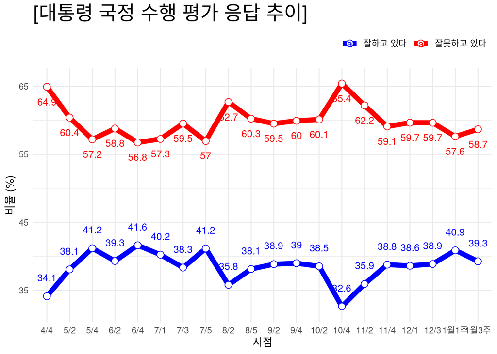

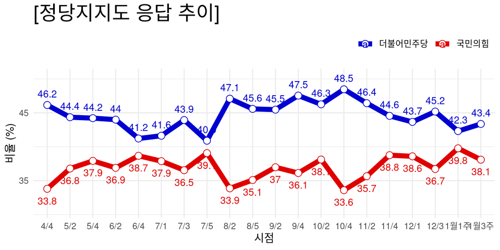

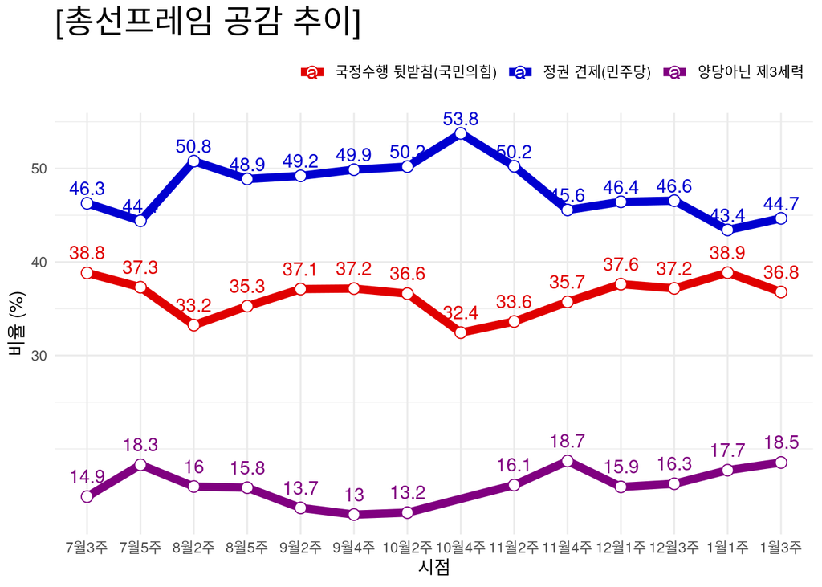

### 추가사항

- [주요질문 / 집단별 세부통계 보기](https://modernity.shinyapps.io/survey_str/) (링크누르시오)

### 참고사항

- 표본수: 2,002명,표본오차는 95% ±2.2%p
- 조사정보: 스트레이트뉴스의 의뢰로 조원씨앤아이가 2024년 1월 13일~2024년 1월15일 3일간

  전국 만 18세 이상 남녀를 대상으로 ARS 여론조사

  (휴대전화 100% RDD 방식, 성,연령대,지역별 비례할당 후 무작위 추출)를 실시한 결과이며,

  표본수는 2,002(총 통화시도 67,098명, 응답률 3.0%)

  ※ 가중치 부여 방식: [림가중] 성별, 연령별, 지역별 가중값 부여(2023년 12월말 행정안전부 발표 주민등록인구기준)
- [중앙선거여론조사심의위원회](https://nesdc.go.kr/portal/bbs/B0000005/list.do?menuNo=200467)에서 관련사항 확인가능

2024.01.17 (수) 16:23 제작

- 연구개발 단계입니다.
- 제공: 감동과 마음의 [조원씨앤아이](http://jowoncni.com/html/index.html)